# Statistics for Data Science: Group Assignment

Group 2

Axel Resnik

Bernardo Palma Nobre

Camille Anna-Sue Cohiba Nobis

Fernando Alvarez Vazquez

Sigridur Sonja Steingrimsdottir

10/25/2023

## Problem Statement

The mission is to estimate the number $N_{max}$ of inhabitants of a planet and investigate the properties of these routines. Each inhabitant is assigned a number from $1$ to $N_{max}$. The numbers collected from a sample of $N = 100$ inhabitants and stored in file `inhabitants.xlsx`.

## Introduction

The underlying goal of this report was to estimate the population size of inhabitants on a small, remote planet where each individual was assigned a unique number ranging from 1 to $N_{max}$. To achieve this, we used the bootstrap technique and resampled the original sample $10,000$ times. To estimate the number of inhabitants we used three different estimators, the first one involved identifying the maximum number (referred as $x_{(N)}$) within each sample. Moreover, the second estimator utilized twice the average of each sample ( (referred to as $2\bar{x}$) to estimate the population size. By utilizing this estimator and by doubling the sample average, we were able to approximate the number of inhabitants. Furthermore, we used an additional metric, the *midpoint estimator*, which was based on the midpoint estimate and calculated by adding the smallest, $x_{(1)}$ and the largest values, $x_{(N)}$, from the sample and subtracting $1$. Creating multiple samples with the bootstrap technique allowed us approximate the sampling distributions for the estimators and to leverage the Central Limit Theorem [CLT], in the case of $2\bar{x}$ estimator, treating the aggregated samples as if they were normally distributed. The CLT aided our efforts in estimating the population size, utilizing the nature of sample means to be approximately normally distributed, especially with large sample sizes (usually $N>30$).

## Possible Estimators for $N_{max}$

The total number of aliens $N_{max}$ will be estimated using the two prescribed estimators that are commonly used for this task, and additionally with the *midpoint estimator* estimator that similarly to the $2\bar{x}$ estimator builds on the independent sampling of the population to estimate the $N_{max}$ as $2\times$ the midpoint:

- The sample maximum $x_{(N)}$: the largest observation in the sample.
- Two times the mean $2\bar{x}$.
- Midpoint estimator $x_{(1)}+x_{(N)}-1$.

## Variability Analysis

The CLT guarantees that the sample mean follows a Normal distribution with mean $\mu$ and standard deviation $\sigma/\sqrt{N}$, where $\mu$ is the population mean, $\sigma$ is the population standard deviation and $N$ is the sample size. This therefore gives that:

- $2\bar{x}$ follows a Normal distribution.
- The mean of $2\bar{x}$ is $2\mu$.
- The standard deviation of $2\bar{x}$ is $2\sigma/\sqrt{N}$, (actually $2s/\sqrt{N}$).

But what can be done with the maximum $x_{(N)}$ and midpoint $x_{(1)}+x_{(N)}-1$ since CLT doesn’t apply?

## The Steps of the Analysis

First the sample data is loaded:

```r
df <- suppressMessages(read_xlsx(path = "inhabitants.xlsx",col_names=FALSE))
alien_sample<-df$...1
```

### Bootstrapping Method

The bootstrapping was deployed with $10,000$ resample runs, with replacement, of the only sample available. This produced $10,000$ pseudo-samples, each representing a variation of our limited data. This resampling process allowed us to approximate the sampling distribution and assess the variability of key statistics without relying on specific assumptions about the underlying data distribution. It’s important to note that through using the bootstrapping technique, we are able to estimate sampling distributions of calculated parameters without having to make any assumptions regarding the population parameters.

### 1. Create Samples ($10,000\times100$)

```r
M=10000 # number of bootstrap samples
set.seed(1999) # for repeatability
# variable init
bootMax<-vector()
boot2x <-vector()
bootMaxPlusMin <-vector()
```

### 2. Bootstrap sample the estimators: $x_{(N)}$, $2\bar{x}$ and $x_{(1)}+x_{(N)}-1$

```r
for(i in 1:M){
  bootSample<-sample(alien_sample,size=length(alien_sample),replace=TRUE)
  bootMax[i]<-max(bootSample)
  boot2x[i]<-2*mean(bootSample)
  bootMaxPlusMin[i]<-max(bootSample)+min(bootSample)-1
}
```

### 3. Calculate Averages

```r
mean2x<-mean(boot2x)
meanMax<-mean(bootMax)
meanMaxPlusMin<-mean(bootMaxPlusMin)
```

1. Mean for $x_{(N)}$: 989.34

The mean for $x_{(N)}$, denoting the sample maximum, reflects the average of the highest values observed within the 10,000 resamples of the original sample.

2. Mean for $2\bar{x}$: 1012.81

The average of $2\times$ the mean calculated for the each of the resamples.

3. Mean for $x_{(1)}+x_{(N)}-1$: 995.28

This number represents the average of $2\times$ the mid point calculated for each of the resamples.

### 4. Standard Deviations

```r
sd2x<-sd(boot2x)
sdMax<-sd(bootMax)
sdMaxPlusMin<-sd(bootMaxPlusMin)
```

1. Standard Deviation for $x_{(N)}$: 11.7

With 10,000 resamples, a standard deviation of 11.7 for x(N) signifies that the observed maximum numbers in our samples exhibits an average standard deviation of approximately 11.7 aliens from the mean which we calculated to be 989.34. This indicates there is not much variability among these estimates.

2. Standard Deviaton for $2\bar{x}$: 58.71

The standard deviation of 58.71 for $2\times$ the mean, reveals that estimates of the overall population size, derived from resampling a single, 100 alien sample, exhibit an average deviation of approximately 58.71 aliens from the mean estimate (1012.81). This implies a relatively broad range of variability in the estimates of population size.

3. Standard Deviation for $x_{(1)}+x_{(N)}-1$: 12.04

Similarly to $x_{(N)}$ this number, indicates that there is not much variability among the estimates compared to the $2\bar{x}$ estimator.

### 5. Confidence Intervals

The main goal, when it comes to the alien planet revolved around the challenging task of estimating the population size ($N_{max}$) with the limited data that was available. The confidence intervals were constructed, using the 2.5% and 97.5% percentiles or a significance level of 95%, ($\alpha$=5%). These intervals allow us to define a range of credible values for the population estimate from each estimator.

1. Confidence Interval for $x_{(N)}$: (953, 994)

This interval indicates that the bootstrap resampling as an approximation to the true sampling distribution for $x_{(N)}$ would, if repeated many times, be 95% of the time in the range (953, 994).

2. Confidence Interval for $2\bar{x}$: (898.04, 1126.79)

This interval provides an estimation of the true overall population size, suggesting it falls within the range of 898.04 to 1126.79, with a confidence level of 95%. This estimation, derived by doubling the mean of our samples, offers valuable insights into the likely range of the total population size. It indicates that the bootstrap resampling as an approximation to the true sampling distribution for $2\bar{x}$, gives the estimate that 95% the time the true value lies the range (898.04, 1126.79)

3. Confidence Interval for $x_{(1)}+x_{(N)}-1$: (957, 1006)

To summarize, these confidence intervals serve as a means to account for the range of values within which the true population parameters are likely to be found. While these intervals provide valuable insights, it’s crucial to acknowledge the potential for error, as they are based on sample data. These confidence intervals play a critical role in our endeavor get an estimate of the population of the alien planet, enabling us to make informed assessments while recognizing the inherent variability and limitations in our data.

### 6. Histograms

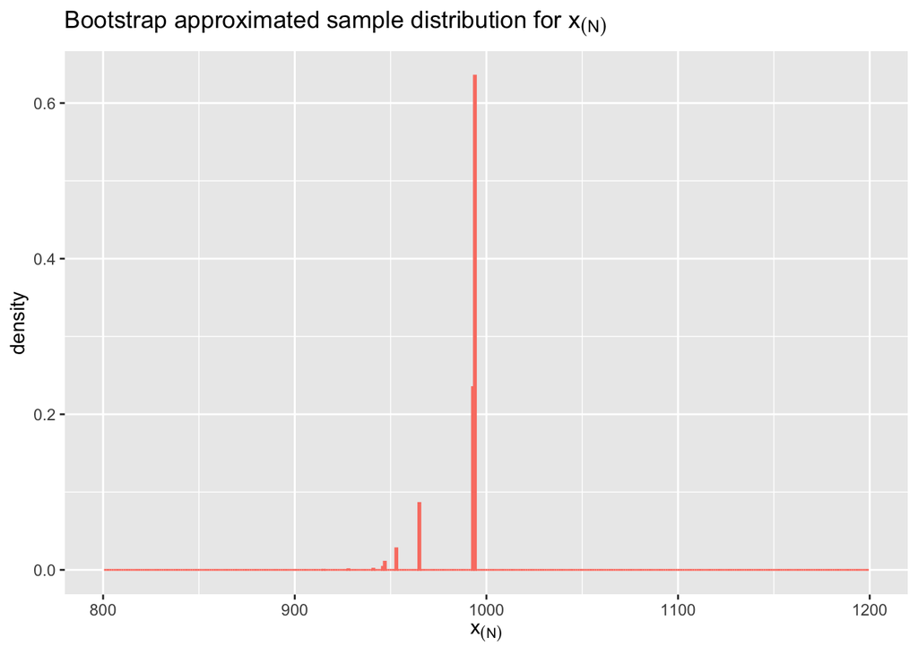

```r
xaxis_min<-800
xaxis_max<-1200

p2 <- ggplot(data.frame(bootMax),aes(x = bootMax)) +
    geom_histogram(aes(y = after_stat(density)),color="salmon",fill="salmon", alpha = 0.75,binwidth=1) +
    ggtitle(expression(paste("Bootstrap approximated sample distribution for ",x[(N)])))+
    xlab(expression(paste(x[(N)]))) +
    xlim(xaxis_min,xaxis_max)
p2
```

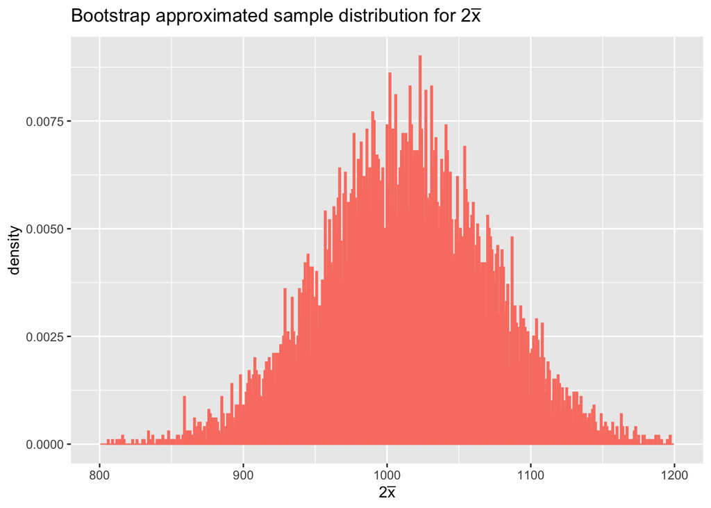

```r
p1 <- ggplot(data.frame(boot2x),aes(x = boot2x)) +
    geom_histogram(aes(y = after_stat(density)),color="salmon",fill="salmon", alpha = 0.75,binwidth=1) +
    ggtitle(expression(paste("Bootstrap approximated sample distribution for 2",bar(x))))+
    xlab(expression(paste("2",bar(x)))) +
    xlim(xaxis_min,xaxis_max)
p1
```

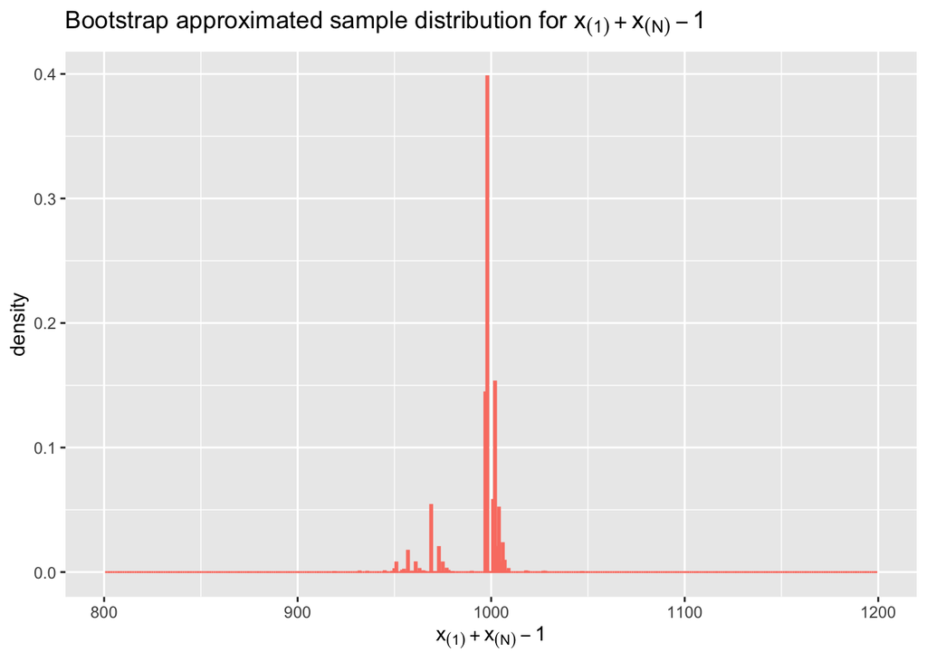

```r
p3 <- ggplot(data.frame(bootMaxPlusMin),aes(x = bootMaxPlusMin)) +
    geom_histogram(aes(y = after_stat(density)),color="salmon",fill="salmon", alpha = 0.75,binwidth=1) +
    ggtitle(expression(paste("Bootstrap approximated sample distribution for ",x[(1)]+x[(N)]-1)))+
    xlab(expression(paste(x[(1)]+x[(N)]-1))) +
    xlim(xaxis_min,xaxis_max)

p3
```

### 7. Critical Comments

The bootstrapping method yields approximates to the sampling distribution of the variable being calculated and in the case of $2\bar{x}$ we can furthermore assume that CLT applies as we are calculating average of 100 independent samples. Applying the CLT and calculating $2s/\sqrt{N}$ we get: $SE$=59.19 but that is very close to the standard deviation of the bootstrap distribution: 58.71. The calculated confidence interval for $2\bar{x}$ is (896.55, 1128.57) which is very close to the values obtained using the bootstrapping simulation.

The CLT neither applies to the $x_{(N)}$ method (nor the $x_{(1)}+x_{(N)}-1$ method) and the bootstrapping result shows indeed a very sparse and left skewed distribution for the $x_{(N)}$ but also very sparse but more symmetric distribution for the $x_{(1)}+x_{(N)}-1$ method. Neither appear to have the shape of a normal distribution.

Comparing the standard deviation values, a noteworthy disparity becomes apparent. This discrepancy can be attributed to the application of the CLT in the $2\bar{x}$ method, where a multitude of values above and below the mean are considered. A consequence of the CLT is that with a given confidence it is known that the real population mean lies in the confidence range. On the contrary, for the other estimators, it is only known that the resampling approximates the true sampling distribution of the variable being sampled and calculated. The narrow confidence intervals of the bootstrapping estimates should therefore be accepted cautiously.

### 8. Further Evaluation

```r
# Can now assume Nmax is known
Nmax<-1000
```

The $2\bar{x}$ method is unbiased [^1] but has somewhat higher standard deviation that the other estimators, as can be seen from the width of the respective bootstrapping distribution. Given that $N_{max}=1000$ one can calculate the mean square error of the bootstrapping simulations as ${\rm MSE}=\frac{1}{n}\sum_{i=1}^{M}(2\bar{x_i}-N_{max})^2=$ 3610.68 that can be compared to the estimated variance 3446.91 as can be expected as each is based on the same dataset (the original sample).

The $x_{(N)}$ method is however biased as expected since: $E\left[x_{(N)}\right]=\sum_{n=1}^{N_{max}}nP(x_{(N)}=n)<N_{max}$ as relatively small part of $100$ alien samples will include $N_{max}$ (see below) and resampling will not change that. The mean square error for $x_{(N)}$ is ${\rm MSE}=\frac{1}{n}\sum_{i=1}^{M}(x_{(N)i}-1000)^2=$ 250.61.

To confirm this we can construct the sampling distribution in the following way. By assumption the samples are independent and counting that there are ${N_{max}\choose n}=\frac{N_{max}!}{n!(N_{max}-n)!}$ unique ways to select $n$ samples from $N_{max}$ numbers $(1..N_{max})$ but if we restrict the sampling to having at least 1 sample equal to $N_{max}$ then that can only be done in ${N_{max}-1\choose n-1}$ unique ways, assuming each individual can only be sampled once each week. The probability that $x_{N}=N_{max}=1000$ is therefore

$$P(x_{N}=N_{max})={N_{max}-1\choose
n-1}/{N_{max}\choose n}=\frac{n}{N_{max}}=100/1000=0.1$$
.

Next step is to calculate the probability that $x_{(N)}=N_{max}-1=999$ but that is

$$P(x_{N}=N_{max}-1)={N_{max}-2\choose
n-1}/{N_{max}\choose n}=\frac{n}{N}\frac{N_{max}-n}{N_{max}-1}$$
and furthermore
$$P(x_{(N)}=N_{max}-z)={N_{max}-z-1\choose
n-1}/{N_{max}\choose
n}=P(x_{(N)}=N_{max}-z+1)\frac{N_{max}-n-z+1}{N_{max}-z}$$
for $z\in \{1,N-n\}$, $P(x_{(N)}=N-z)=0$ for $z>N-n$.

The expected value for $x_{(N)}$ can now be calculated as:
$$E[x_{(N)}]=\frac{1}{N_{max}}\sum_{z=0}^{N_{max}}(N_{max}-z)P(x_{(N)}=N_{max}-z)$$
.

```r
n<-100
Exn<-0
sumPxn<-0
for(z in 0:(Nmax-n)){
  if (z==0) {
    Pxn<-n/Nmax
  } else
  {
    Pxn<-Pxn*(Nmax-n-z+1)/(Nmax-z)
  }
  Exn<-Exn+Pxn*(Nmax-z)
  sumPxn<-sumPxn+Pxn

}
Exn
```

```
## [1] 991.0891
```

```r
#sumPxn
```

So the bias is $N_{max}-E\left[x_{(N)}\right]\approx$ 9. The variance of the sampling distribution can be calculated as

```r
var_xN<-0

for(z in 0:(Nmax-n)){
  if (z==0) {
    Pxn<-n/Nmax
    Pxnv<-c(Pxn)
  } else
  {
    Pxn<-Pxn*(Nmax-n-z+1)/(Nmax-z)
    Pxnv<-append(Pxnv,Pxn)
  }
  var_xN<-var_xN+Pxn*(Nmax-z-Exn)^2

}
Pxnv900<-0*c(0:110)
Pxnv900[0:100]=rev(Pxnv[0:100])
Ni<-900:1010
df<-data.frame(Ni,Pxnv900)
names(df)<-c("xN","PxN")
round(var_xN,digits=2)
```

```
## [1] 86.58
```

That can be compared to $s_{x_{N}}^2$=136.91.This computed theoretical variance calculation is based on the assumption that the data is samples are independent from a uniform population. If the data is not from a uniform distribution, the theoretical variance calculation may not be accurate. The estimated variance is based on the bootstrap samples, which are resamples of the original sample.

A picture of the sampling distribution for $x_{(N)}$ shows the bias:

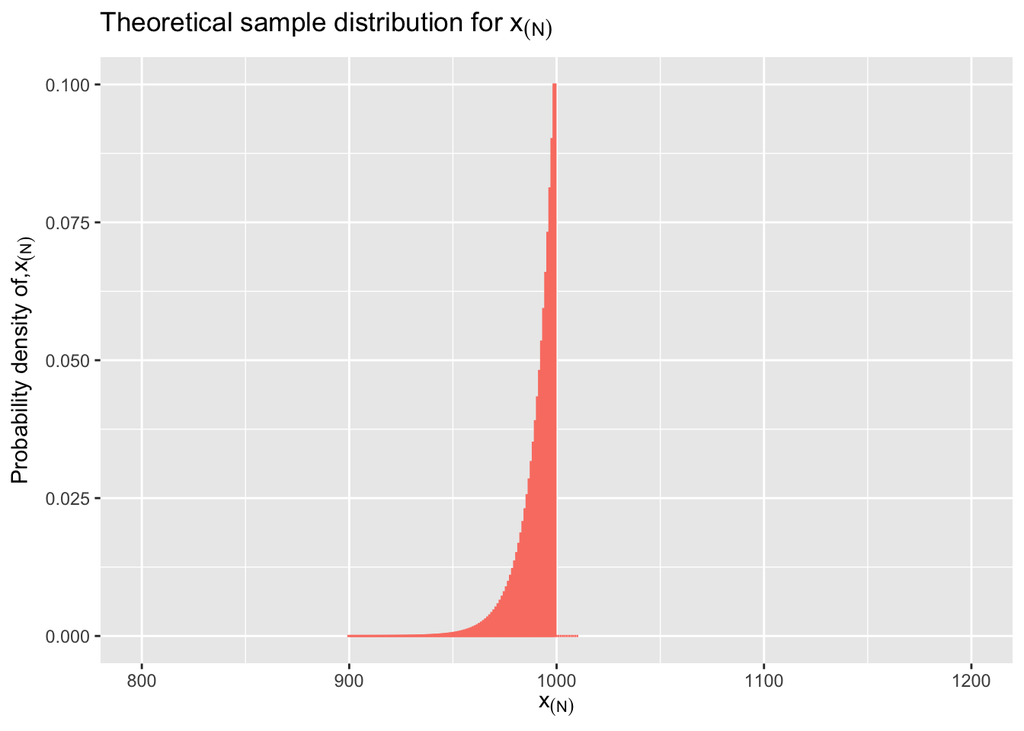

```r
p1 <- ggplot(df,aes(x=xN,y=PxN)) +
    geom_bar(stat="identity",color="salmon",fill="salmon", alpha = 0.75) +
#    geom_histogram(aes(x = bootMax),color="cyan",fill="cyan", alpha = 0.75) +
#   ggtitle("Sample distribution for x_N") +
    ggtitle(expression(paste("Theoretical sample distribution for ",x[(N)])))+
    xlab(expression(paste(x[(N)]))) +
    ylab(expression(paste("Probability density of,",x[(N)])))+
    xlim(xaxis_min,xaxis_max)
p1
```

The distribution is not centered around the true mean of the population. Instead, the distribution is skewed to the left, which means that the $x_{(N)}$ estimator will underestimate the true mean of the population.

For the alternative estimator $x_{(1)}+x_{(N)}-1$ we can, using symmetry, write down the probability that $x_{(1)}=z+1$ as

$$P(x_{(1)}=z+1)={N_{max}-z-1\choose
n-1}/{N_{max}\choose
n}=P(x_{(1)}=z)\frac{N_{max}-n-z+1}{N_{max}-z}$$
for $z\in \{1,N-n\}$ and $P(x_{(1)}=1)=\frac{n}{N_{max}}=\frac{100}{1000}=0.1$.

Calculating

$$E\left[x_{(1)}+x_{(N)}-1\right]=E\left[x_{(1)}\right]+E\left[x_{(N)}\right]-1=
\\
\sum_{z=0}^{z=N-n}P(x_{(1)}=z+1)(z+1)+\sum_{z=0}^{z=N-n}P(x_{(N)}=N_{max}-z)(N_{max}-z)
-1 \\ =(N_{max}+1)\sum_{z=0}^{z=N-n}\left[P(z)\right]-1=N_{max}$$
since $P(x_{(1)}=z+1)=P(x_{(N)}=N_{max}-z)$

Calculating the expected value from the probability distribution for $x_{(1)}+x_{(N)}-1$:

```r
n<-100
Nmax<-1000
Ex1pxn<- -1
for(z in 0:(Nmax-n)){
  if (z==0) {
    Pxn<-n/Nmax
  } else
  {
    Pxn<-Pxn*(Nmax-n-z+1)/(Nmax-z)
  }
  Ex1pxn<-Ex1pxn+Pxn*(Nmax-z)+Pxn*(z+1)
}
Ex1pxn
```

```
## [1] 1000
```

We get $E\left[x_{(1)}+x_{(N)}-1\right]=$ 1000 $=N_{max}$.

The sampling distribution for $x_{(1)}+x_{(N)}-1$ can be calculated by convolution, i.e. summing up the joint probabilities where $x_{(1)}+x_{(N)}-1=x_{(i)}$

```r
# calculate only for the 100 values left of x_i=1000, i.e. x_i in [901-1001]
# not necessary to go further as probs are ~0 there
for(zz in 900:999){
   Sj<-0
   for(i in 0:100)
      {Sj<-Sj+Pxnv[i+1]*Pxnv[Nmax-zz+i]}
   if(zz==900)
    {P1nv<-c(Sj)
     #print(Sj)
     }
   else
   {P1nv<-append(P1nv,Sj)
     #print(Sj)
     }
  }


P1nvt<-append(P1nv,rev(P1nv[1:99]))
xn<-c(901:1099)
df1N<-data.frame(xn,P1nvt)
names(df1N)<-c("xN","Px1N")
# check sum of probs, should be ~1.0
sum(P1nvt)
```

```
## [1] 0.9999853
```

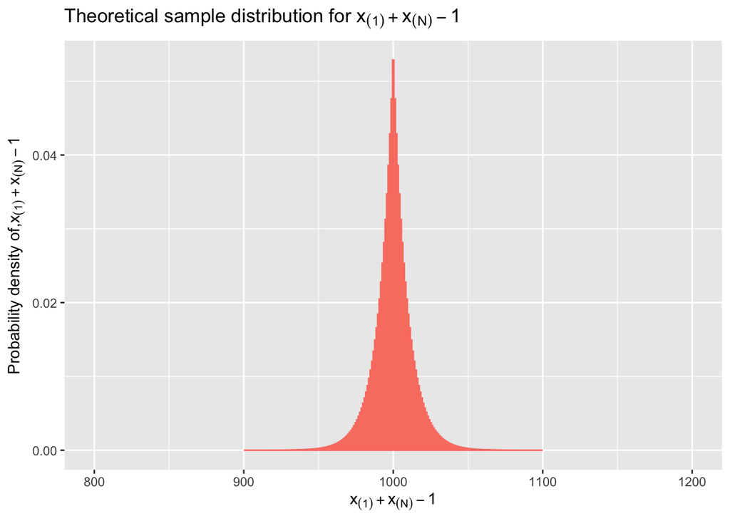

```r
p1 <- ggplot(df1N,aes(x=xN,y=Px1N)) +
    geom_bar(stat="identity",color="salmon",fill="salmon", alpha = 0.75) +
#    geom_histogram(aes(x = bootMax),color="cyan",fill="cyan", alpha = 0.75) +
    ggtitle(expression(paste("Theoretical sample distribution for ",x[(1)]+x[(N)]-1)))+
    xlab(expression(paste(x[(1)]+x[(N)]-1))) +
    ylab(expression(paste("Probability density of,",x[(1)]+x[(N)]-1)))+
    xlim(xaxis_min,xaxis_max)

p1
```

Can use the sampling distribution to estimate
$$\sigma_{x_{(1)}+x_{(N)}-1}^2=\sum_{x_{(i)}=n}^{2N_{max}-n}P(x_{(1)}+x_{(N)}-1=x_{(i)}){(x_{(i)}-N_{max})^2}$$

```r
# Only need the values Nmax-100 to Nmax+100 as P~0 elsewhere
sigma2x1pxn<-sum(df1N$Px1N*(df1N$xN-Nmax)^2)
sigma2x1pxn
```

```
## [1] 172.9944
```

That can be compared to the bootstrapping squared standard deviation: $s_{x_{N}+x_{N}-1}^2$=145.02.

The choice of an estimator depends on the specific needs of a particular analysis and the trade-offs one is willing to make between bias and variability.

However, the bias values show opposing tendencies in estimation. The positive bias for $2\bar{x}$ suggests overestimation, while the negative bias for $x_{(N)}$ indicates underestimation in relation to the true population size.

With this there are some trade-offs to take into account when deciding with which of the estimators to go with.

**Trade-off Between Over and Underestimation:** Which type of error (over or underestimation) would have a greater impact on the decisions or outcomes based on the estimation? This would be the perfect question to assess which of the estimators is better to use, because it will all depend on the decision in question. In scenarios where overestimation is detrimental, an estimator that tends to overestimate might not be ideal.

**Trade-off between Robustness and Accuracy:** The $x_{(N)}$ estimator, being more conservative, is robust against assumptions about the sample distribution. It provides an estimate that is less sensitive to deviations from the distributional assumptions, offering stability and less susceptibility to extreme observations or non-normally distributed data. However, the $2\bar{x}$ estimator might yield more accurate results if the assumption of a normal distribution holds. However, it is highly sensitive to the accuracy of the assumption and can yield drastically wrong estimates if the true sample distribution deviates significantly from normality. There is a good analogy of “going all in” in poker for the estimator and a more conservative approach for the $x_{(N)}$ estimator perfectly mirrors this trade-off. The $2\bar{x}$ estimator heavily relies on the assumption that the sample data conforms to a normal distribution, akin to the bold strategy in poker. If this assumption holds, it could provide an accurate estimate similar to going “all in” and winning big. However, if the assumption fails, it might result in a substantial loss, reflecting an inaccurate estimate. In contrast, the $x_{(N)}$ estimator takes a more conservative approach, relying on a simpler premise without stringent assumptions about the data distribution, akin to a more risk-averse strategy in poker. This makes it less susceptible to losses in estimation accuracy due to deviations from distributional assumptions.

The choice of estimator depends on the specific needs of a particular analysis and the trade-offs one is willing to make between bias and variability.

### Conclusion

In conclusion, our statistical analysis aimed to estimate the population size of inhabitants on a small, remote planet, each assigned a unique number ranging from 1 to $N_{max}$. The total population $N_{max}$ was estimated using the bootstrap technique with $10,000$ resamples and three different estimators: $2\bar{x}$, $x_{(N)}$, and the $x_{(1)}+x_{(N)}-1$ estimators.

Our findings revealed important trade-offs between bias and variability in these estimation methods. The $2\bar{x}$ estimator demonstrated unbiased results but exhibited high variability. In contrast, the $x_(N)$ estimator, while biased, displayed lower variability, tending to underestimate the population mean, but the $x_{(1)}+x_{(N)}-1$ estimator appeared as balanced approach.

[^1]: The $2\bar{x}$ method is unbiased because it is a weighted average of the data, and the weights are chosen in such a way that the average is equal to the true mean.